# CUSTOMER SEGMENTATION

Understanding customers is critical for success and survival of a Business. Knowing our customers helps a Business to provide products and service that lead to extreme customer satisfaction and help towards the growth of the Business.  
Customer segmentation can help strategies Business effectively. Customer segmentation is a process of dividing customers based on similar characteristics – such as demographics or behaviors into groups called clusters. These Customer Segments/ Groups can help Businesses to cater each segment of customer uniquely.

In this project, I will be performing an unsupervised clustering of customer's records from a Retail Chain.

### Please vote up and share your feedback in the comment box, if you like this notebook.

[figure not shown]

# **TABLE OF CONTENTS**

- 1. Load Required Libraries
- 1. Load Data and Over View
- 1. EDA & Data Cleaning
- 1. Data Preprocessing
- 1. Dimensionality Reduction with PCA
- 1. Clustering
- 1. Extracting Cluster Characteristics
- 1. Customer Profiling
- 1. Conclusion

## **Load Required Libraries**

```python
import numpy as np
import pandas as pd
import datetime as dt
from datetime import date
import matplotlib
import seaborn as sns
import matplotlib.pyplot as plt
from numpy import unique
from numpy import where
from sklearn.decomposition import PCA

from sklearn.preprocessing import StandardScaler

from sklearn import metrics
import os

import warnings
import sys
if not sys.warnoptions:
    warnings.simplefilter("ignore")
np.random.seed(0)
```

```python
from sklearn.cluster import KMeans
from sklearn.cluster import AgglomerativeClustering
from sklearn.cluster import Birch
from sklearn.mixture import GaussianMixture
```

```python
%matplotlib inline
sns.set_style("white")

class color:
   BLUE = '\033[94m'
   BOLD = '\033[1m'
   END = '\033[0m'
```

## **Load Data and Over View**

# Load Dataset

Dataset [here](https://www.kaggle.com/imakash3011/customer-personality-analysis).

```python
data = pd.read_csv("marketing_campaign.csv", sep="\t")
data.head()
```

|  | ID | Year_Birth | Education | Marital_Status | Income | Kidhome | Teenhome | Dt_Customer | Recency | MntWines | ... | NumWebVisitsMonth | AcceptedCmp3 | AcceptedCmp4 | AcceptedCmp5 | AcceptedCmp1 | AcceptedCmp2 | Complain | Z_CostContact | Z_Revenue | Response |
| --- | --- | --- | --- | --- | --- | --- | --- | --- | --- | --- | --- | --- | --- | --- | --- | --- | --- | --- | --- | --- | --- |
| 0 | 5524 | 1957 | Graduation | Single | 58138.0 | 0 | 0 | 04-09-2012 | 58 | 635 | ... | 7 | 0 | 0 | 0 | 0 | 0 | 0 | 3 | 11 | 1 |
| 1 | 2174 | 1954 | Graduation | Single | 46344.0 | 1 | 1 | 08-03-2014 | 38 | 11 | ... | 5 | 0 | 0 | 0 | 0 | 0 | 0 | 3 | 11 | 0 |
| 2 | 4141 | 1965 | Graduation | Together | 71613.0 | 0 | 0 | 21-08-2013 | 26 | 426 | ... | 4 | 0 | 0 | 0 | 0 | 0 | 0 | 3 | 11 | 0 |
| 3 | 6182 | 1984 | Graduation | Together | 26646.0 | 1 | 0 | 10-02-2014 | 26 | 11 | ... | 6 | 0 | 0 | 0 | 0 | 0 | 0 | 3 | 11 | 0 |
| 4 | 5324 | 1981 | PhD | Married | 58293.0 | 1 | 0 | 19-01-2014 | 94 | 173 | ... | 5 | 0 | 0 | 0 | 0 | 0 | 0 | 3 | 11 | 0 |

5 rows × 29 columns

# Data Overview

Let us look at the data.

```python
print(color.BOLD + "There are {} entries and {} variables in the dataset.".format(data.shape[0],data.shape[1]),"\n"+ color.END)
```

```
There are 2240 entries and 29 variables in the dataset.
```

[figure not shown]

**Customer information**

1. ID: Customer's unique identifier.
2. Year_Birth: Customer's birth year.
3. Education: Customer's education level.
4. Marital_Status: Customer's marital status.
5. Income: Customer's yearly household income.
6. Kidhome: Number of children in customer's household.
7. Teenhome: Number of teenagers in customer's household.
8. Dt_Customer: Date of customer's enrollment with the company.
9. Recency: Number of days since customer's last purchase.
10. Complain: 1 if customer complained in the last 2 years, 0 otherwise.

**Purchases**

1. MntWines: Amount spent on wine in last 2 years.
2. MntFruits: Amount spent on fruits in last 2 years.
3. MntMeatProducts: Amount spent on meat in last 2 years.
4. MntFishProducts: Amount spent on fish in last 2 years.
5. MntSweetProducts: Amount spent on sweets in last 2 years.
6. MntGoldProds: Amount spent on gold in last 2 years.

**Promotion**

1. NumDealsPurchases: Number of purchases made with a discount.
2. AcceptedCmp1: 1 if customer accepted the offer in the 1st campaign, 0 otherwise.
3. AcceptedCmp2: 1 if customer accepted the offer in the 2nd campaign, 0 otherwise.
4. AcceptedCmp3: 1 if customer accepted the offer in the 3rd campaign, 0 otherwise.
5. AcceptedCmp4: 1 if customer accepted the offer in the 4th campaign, 0 otherwise.
6. AcceptedCmp5: 1 if customer accepted the offer in the 5th campaign, 0 otherwise.
7. Response: 1 if customer accepted the offer in the last campaign, 0 otherwise.

**Purchase Source**

1. NumWebPurchases: Number of purchases made through the company’s web site.
2. NumCatalogPurchases: Number of purchases made using a catalogue.
3. NumStorePurchases: Number of purchases made directly in stores.
4. NumWebVisitsMonth: Number of visits to company’s web site in the last month.

## **Exploratory Data Analysis & Data Cleaning**

Exploratory data analysis is the first and most important phase in any data analysis.  
In this session we aim to ,examine data, uncover important patterns and to make sense of it.

In this EDA section we will cover the following steps:

1. Data cleaning
2. Univariate analysis
3. Bi-variate/Multivariate analysis

```python
print(color.BOLD +color.BLUE +"Let's look at the data types available in the dataset"+ color.END)
data.info()
```

```
Let's look at the data types available in the dataset
<class 'pandas.core.frame.DataFrame'>
RangeIndex: 2240 entries, 0 to 2239
Data columns (total 29 columns):
 #   Column               Non-Null Count  Dtype
---  ------               --------------  -----
 0   ID                   2240 non-null   int64
 1   Year_Birth           2240 non-null   int64
 2   Education            2240 non-null   object
 3   Marital_Status       2240 non-null   object
 4   Income               2216 non-null   float64
 5   Kidhome              2240 non-null   int64
 6   Teenhome             2240 non-null   int64
 7   Dt_Customer          2240 non-null   object
 8   Recency              2240 non-null   int64
```

[output cut: 22 more lines]

**Categorical Variables**

# Create Visualization for Categorical Variables

```
Number of unique values in Education is 5
```

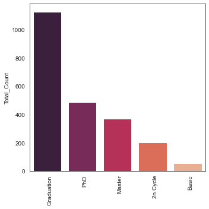

```
 -------------------------------------------------------------------------------------------------
Number of unique values in Marital_Status is 8
```

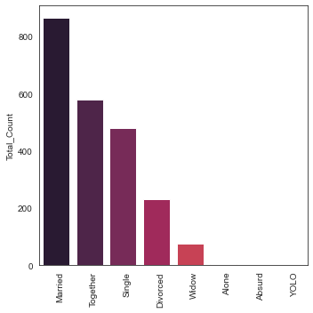

```
 -------------------------------------------------------------------------------------------------
Number of unique values in Kidhome is 3
```

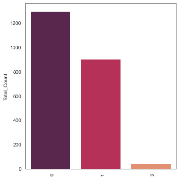

```
 -------------------------------------------------------------------------------------------------
Number of unique values in Teenhome is 3
```

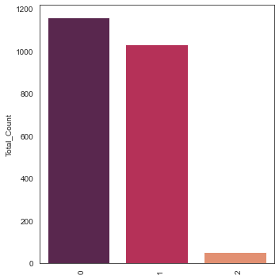

```
 -------------------------------------------------------------------------------------------------
Number of unique values in Complain is 2
```

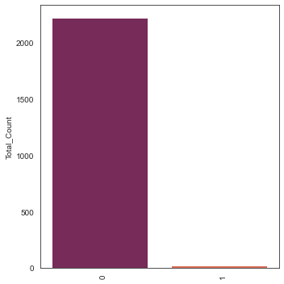

```python
%matplotlib inline
Cust_details_col=['Education', 'Marital_Status', 'Kidhome', 'Teenhome', 'Complain']

for column in Cust_details_col:
    count_uniques = pd.DataFrame(data[column].value_counts()).rename(columns={column:'Total_Count'}).sort_values('Total_Count',ascending=False)

    # parameters in format function.
    print(color.BOLD +"Number of unique values in {} is {}".format(column, count_uniques.shape[0]), "\n"+ color.END)

    # Create Figure
    fig, ax = plt.subplots(figsize=(5,5))

    ax = sns.barplot(x=count_uniques.index.values.tolist()  , y="Total_Count", data=count_uniques, palette= 'rocket')
    # rotates labels and aligns them horizontally to left
    plt.setp( ax.xaxis.get_majorticklabels(), rotation=90, ha="left" )

    plt.tight_layout()
    plt.show()

    print("\n",'-------------------------------------------------------------------------------------------------')
```

# Creating New Variables

I will create new variables to extract relevant information from existing variables:

1. Create "Children" adding kids and teenagers.
2. Encode Kidhome and Teenhome into binary
3. Create"Family_Size" to indicate number of people in household
4. Create "Relation_status" from "Marital_Status"
5. Simplify "Education" by combining the levels.

### Children

Create column "Children" by adding kids and teenagers.

```python
column_names = ['Kidhome', 'Teenhome']
data['Children']= data[column_names].sum(axis=1)
```

### Family_Size

If Marital_Status is 'Married'/'Together' count members in the house as 2 and then add number of children from column created above. This gives us family size.

```python
Marital_Status = ['Married','Together']
data['Family_Size'] = data['Marital_Status'].apply(lambda x: 2 if x in Marital_Status else 1)
data['Family_Size'] = data.apply (lambda row: row['Family_Size']+row['Children'], axis=1)
```

### Teenhome and Kidhome

Encode these variables.If the value in either of columns Teenhome and Kidhome is not 0 then 1 else 0

```python
data["Teenhome"] = np.where(data.Teenhome> 0, 1, 0)
data["Kidhome"] = np.where(data.Kidhome> 0, 1, 0)
```

### Relation_status

Create a binary variable with 1 and 0. If Marital_Status is 'Married'/'Together' 1 else 0

```python
Marital_Status = ['Married','Together']
data['Relation_status'] = data['Marital_Status'].apply(lambda x: 1 if x in Marital_Status else 0)
```

### Education

Combine levels of education into 3 levels Basic and 2n Cycle as Undergraduate, Graduation o Graduate, Master and PhD to Postgraduate.

```python
#Segmenting education levels in three groups
data["Education"] = data["Education"].replace({"Basic":"Undergraduate", "2n Cycle":"Undergraduate",
                                               "Graduation":"Graduate",
                                               "Master":"Postgraduate", "PhD":"Postgraduate"})
```

```python
#pd.DataFrame(data[['Complain']].value_counts()).apply(lambda x: x/2240*100)
```

*50.3% of Customers in the dataset are "Graduates".  
*38.2% of Customers in the dataset are "Post Graduates".  
*11.4% of Customers in the dataset are "Under Graduates".

*64.4% of Customers are either Married or are in a Relationship.  
*42.2% of Customers have either 1 or 2 Kids at home.  
*48.3% of Customers have either 1 or 2 Teens at home.

*1.4% of Customers have 5 members in the family.  
*39.6% of Customers have 3 members in the family.  
*24.6% of 3 member family have a Teenager at home.  
*20.8% of 3 member family have a Kid at home.  
*14.36% Customers with Kids are Single parents (Single, Divorced and Widowed).  
*16.1% Customers with Teenagers are Single parents (Single, Divorced and Widowed).

*99% of Customers have not made any complains in the last 2 years.

**Numeric Variables**

# Create Visualization for Numeric Variables

### Income

```
count      2216.000000
mean      52247.251354
std       25173.076661
min        1730.000000
25%       35303.000000
50%       51381.500000
75%       68522.000000
max      666666.000000
Name: Income, dtype: float64
```

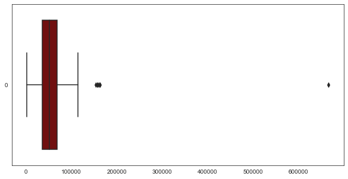

```python
fig, axes = plt.subplots(figsize=(10,5))
sns.boxplot(data=data.Income, color= 'Maroon', orient="h");
data.Income.describe()
```

```python
print(color.BOLD +'There are {} entries where income is > 1,00,000'.format((data.Income >100000).sum())+ color.END)
print(color.BOLD +'There are {}% entries where income is <= 1,00,000'.format(round(((data.Income <=100000).sum()/data.shape[0])*100,2))+ color.END)
print(color.BOLD +"99% value in income is {}".format(round(data.Income.quantile(0.99),2))+ color.END)
```

```
There are 13 entries where income is > 1,00,000
There are 98.35% entries where income is <= 1,00,000
99% value in income is 94458.8
```

Looks like there is an outlier in Income variable (max income value 666666), we will replace this value with NaN and impute this value later.

```python
print(color.BOLD +'Entries with max income value 666666',"\n"+ color.END)
data[data['Income']==666666]
```

```
Entries with max income value 666666
```

|  | ID | Year_Birth | Education | Marital_Status | Income | Kidhome | Teenhome | Dt_Customer | Recency | MntWines | ... | AcceptedCmp5 | AcceptedCmp1 | AcceptedCmp2 | Complain | Z_CostContact | Z_Revenue | Response | Children | Family_Size | Relation_status |
| --- | --- | --- | --- | --- | --- | --- | --- | --- | --- | --- | --- | --- | --- | --- | --- | --- | --- | --- | --- | --- | --- |
| 2233 | 9432 | 1977 | Graduate | Together | 666666.0 | 1 | 0 | 02-06-2013 | 23 | 9 | ... | 0 | 0 | 0 | 0 | 3 | 11 | 0 | 1 | 3 | 1 |

1 rows × 32 columns

```python
data['Income'].replace(666666, np.nan, inplace=True)
```

### Recency

```
count    2240.000000
mean       49.109375
std        28.962453
min         0.000000
25%        24.000000
50%        49.000000
75%        74.000000
max        99.000000
Name: Recency, dtype: float64
```

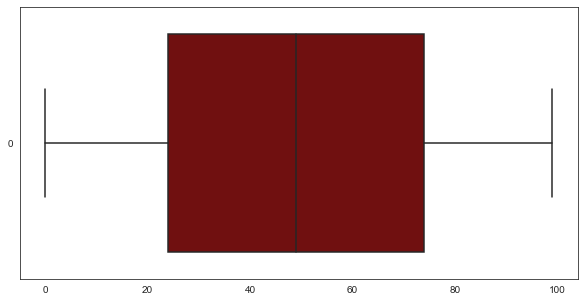

```python
fig, axes = plt.subplots(figsize=(10,5))
sns.boxplot(data=data.Recency, color= 'Maroon', orient="h");
data.Recency.describe()
```

Data is disitributed evenly and there are no outliers

### Variables under Purchase Source and NumDealsPurchases

```python
# Create subset of numeric variables from the dataset
purchase_sourse_cols = ['NumDealsPurchases', 'NumWebPurchases', 'NumCatalogPurchases', 'NumStorePurchases', 'NumWebVisitsMonth']
```

```
Number of unique values in NumDealsPurchases is 15
```

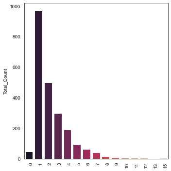

```
 -------------------------------------------------------------------------------------------------
Number of unique values in NumWebPurchases is 15
```

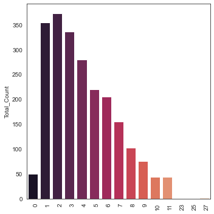

```
 -------------------------------------------------------------------------------------------------
Number of unique values in NumCatalogPurchases is 14
```

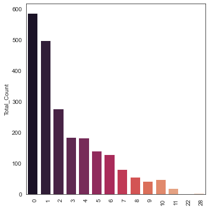

```
 -------------------------------------------------------------------------------------------------
Number of unique values in NumStorePurchases is 14
```

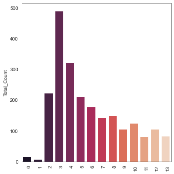

```
 -------------------------------------------------------------------------------------------------
Number of unique values in NumWebVisitsMonth is 16
```

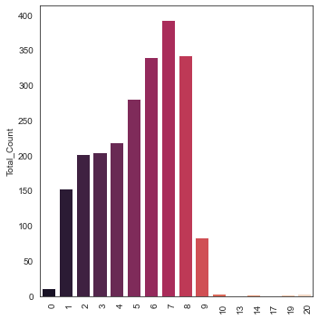

```python
for column in purchase_sourse_cols:
    count_uniques = pd.DataFrame(data[column].value_counts()).rename(columns={column:'Total_Count'}).sort_values('Total_Count',ascending=False)

    # parameters in format function.
    print(color.BOLD +"Number of unique values in {} is {}".format(column, count_uniques.shape[0]), "\n"+ color.END)

    # Create Figure
    fig, ax = plt.subplots(figsize=(5,5))

    ax = sns.barplot(x=count_uniques.index.values.tolist()  , y="Total_Count", data=count_uniques, palette= 'rocket')
    # rotates labels and aligns them horizontally to left
    plt.setp( ax.xaxis.get_majorticklabels(), rotation=90, ha="left" )

    plt.tight_layout()
    plt.show()

    print("\n",'-------------------------------------------------------------------------------------------------')
```

### Variables under Promotion

```python
# Create subset of numeric variables from the dataset
Promotion = ['AcceptedCmp1', 'AcceptedCmp2', 'AcceptedCmp3', 'AcceptedCmp4', 'AcceptedCmp5', 'Response']
```

```
Number of unique values in AcceptedCmp1 is 2
```

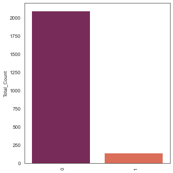

```
 -------------------------------------------------------------------------------------------------
Number of unique values in AcceptedCmp2 is 2
```

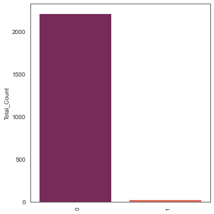

```
 -------------------------------------------------------------------------------------------------
Number of unique values in AcceptedCmp3 is 2
```

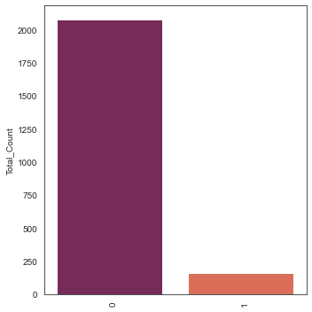

```
 -------------------------------------------------------------------------------------------------
Number of unique values in AcceptedCmp4 is 2
```

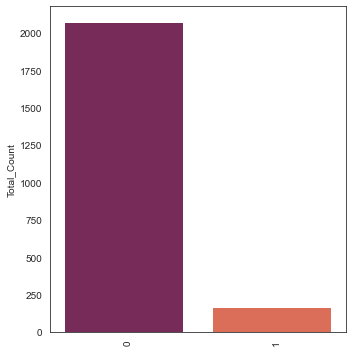

```
 -------------------------------------------------------------------------------------------------
Number of unique values in AcceptedCmp5 is 2
```

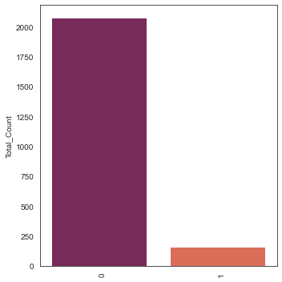

```
 -------------------------------------------------------------------------------------------------
Number of unique values in Response is 2
```

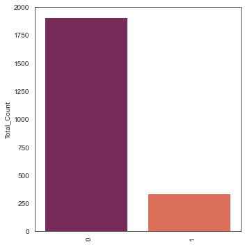

```python
for column in Promotion:
    count_uniques = pd.DataFrame(data[column].value_counts()).rename(columns={column:'Total_Count'}).sort_values('Total_Count',ascending=False)

    # parameters in format function.
    print(color.BOLD +"Number of unique values in {} is {}".format(column, count_uniques.shape[0]), "\n"+ color.END)

    # Create Figure
    fig, ax = plt.subplots(figsize=(5,5))

    ax = sns.barplot(x=count_uniques.index.values.tolist()  , y="Total_Count", data=count_uniques, palette= 'rocket')
    # rotates labels and aligns them horizontally to left
    plt.setp( ax.xaxis.get_majorticklabels(), rotation=90, ha="left" )

    plt.tight_layout()
    plt.show()

    print("\n",'-------------------------------------------------------------------------------------------------')
```

All variables under Promotion have 0 or 1 in thte values.

*About 15% customers responded to campaigns and most of them accepted the deals in 3rd, 4th and 5th campaign.  
*Very few customers responded to 2nd campaign.  
*Response to the last campaign is relatively better than other campaigns.

### variables under Purchases

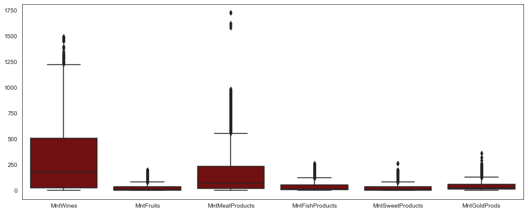

```python
# Create subset of numeric variables from the dataset
numeric_columns = ['MntWines', 'MntFruits', 'MntMeatProducts', 'MntFishProducts', 'MntSweetProducts', 'MntGoldProds']
numeric_df = data[numeric_columns]

fig, axes = plt.subplots(figsize=(15, 6))

sns.boxplot(data=numeric_df, color= 'Maroon');
```

```python
print(color.BOLD +color.BLUE +"\n","Summary statistics of these variables"+ color.END)
numeric_df.describe()
```

```
 Summary statistics of these variables
```

|  | MntWines | MntFruits | MntMeatProducts | MntFishProducts | MntSweetProducts | MntGoldProds |
| --- | --- | --- | --- | --- | --- | --- |
| count | 2240.000000 | 2240.000000 | 2240.000000 | 2240.000000 | 2240.000000 | 2240.000000 |
| mean | 303.935714 | 26.302232 | 166.950000 | 37.525446 | 27.062946 | 44.021875 |
| std | 336.597393 | 39.773434 | 225.715373 | 54.628979 | 41.280498 | 52.167439 |
| min | 0.000000 | 0.000000 | 0.000000 | 0.000000 | 0.000000 | 0.000000 |
| 25% | 23.750000 | 1.000000 | 16.000000 | 3.000000 | 1.000000 | 9.000000 |
| 50% | 173.500000 | 8.000000 | 67.000000 | 12.000000 | 8.000000 | 24.000000 |
| 75% | 504.250000 | 33.000000 | 232.000000 | 50.000000 | 33.000000 | 56.000000 |
| max | 1493.000000 | 199.000000 | 1725.000000 | 259.000000 | 263.000000 | 362.000000 |

```python
print(color.BOLD +color.BLUE +"\n","Total spending in each of Wines, Fruits, MeatProducts, FishProducts, SweetProducts, GoldProds categories is"+ color.END)
numeric_df.sum(axis = 0, skipna = True)
```

```
 Total spending in each of Wines, Fruits, MeatProducts, FishProducts, SweetProducts, GoldProds categories is
```

```
MntWines            680816
MntFruits            58917
MntMeatProducts     373968
MntFishProducts      84057
MntSweetProducts     60621
MntGoldProds         98609
dtype: int64
```

*Wines followed by Meat Products are the most popular selling categories.  
*Total Spending on fruits is 12 times less compared to spending on Wines.  
*Total Spending on Fruits and Sweet Products is almost same

# Creating New variables

I will create new variables to extract relevant information from existing variables:

1. Extract "Age" of customer from Year_Birth variable and drop Year variable.
2. Calculate number of day a customer is registered (days_registered) with the retail store till date.
3. Create "Spending" adding total amount spent in various categories over the span of two years.

### Age

Extract "Age" of customer from Year_Birth variable and drop Year variable.

```python
current_year = dt.datetime.now().year #get current year
data["Age"] = data['Year_Birth'].apply(lambda x: current_year-x)  # substract to get the year delta
#drop Year_Birth
```

```
count    2240.000000
mean       53.194196
std        11.984069
min        26.000000
25%        45.000000
50%        52.000000
75%        63.000000
max       129.000000
Name: Age, dtype: float64
```

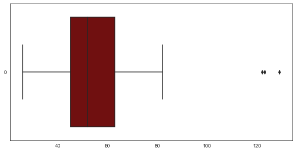

```python
fig, axes = plt.subplots(figsize=(10, 5))
sns.boxplot(data=data['Age'], color= 'Maroon', orient="h" );
data.Age.describe()
```

Looks like there are entries where age is above 100. Looks like the year of data birth is incorrect, we will replace corresponding age values accordingly.

```python
print(color.BOLD +'Print entries with Age above 100',"\n"+ color.END)
data[data['Age']>=100]
```

```
Print entries with Age above 100
```

|  | ID | Year_Birth | Education | Marital_Status | Income | Kidhome | Teenhome | Dt_Customer | Recency | MntWines | ... | AcceptedCmp1 | AcceptedCmp2 | Complain | Z_CostContact | Z_Revenue | Response | Children | Family_Size | Relation_status | Age |
| --- | --- | --- | --- | --- | --- | --- | --- | --- | --- | --- | --- | --- | --- | --- | --- | --- | --- | --- | --- | --- | --- |
| 192 | 7829 | 1900 | Undergraduate | Divorced | 36640.0 | 1 | 0 | 26-09-2013 | 99 | 15 | ... | 0 | 0 | 1 | 3 | 11 | 0 | 1 | 2 | 0 | 122 |
| 239 | 11004 | 1893 | Undergraduate | Single | 60182.0 | 0 | 1 | 17-05-2014 | 23 | 8 | ... | 0 | 0 | 0 | 3 | 11 | 0 | 1 | 2 | 0 | 129 |
| 339 | 1150 | 1899 | Postgraduate | Together | 83532.0 | 0 | 0 | 26-09-2013 | 36 | 755 | ... | 0 | 0 | 0 | 3 | 11 | 0 | 0 | 2 | 1 | 123 |

3 rows × 33 columns

Replace the age by removing the hundreds place

```python
data['Age'].replace(to_replace =[122,129,123],  value =[22,29,23], inplace=True)
```

### Days_Registered

Calculate number of days a customer is registered (Days_Registered) with the retail store till date.

```python
current_day = pd.to_datetime('today').strftime("%d-%m-%Y")
current_day = pd.to_datetime(current_day, format='%d-%m-%Y')
```

```python
#convert variable to date time
data['Dt_Customer'] = pd.to_datetime(data['Dt_Customer'], format='%d-%m-%Y')
```

```python
data['Days_Registered'] = (current_day-data['Dt_Customer']).dt.days
#drop Dt_Customer
```

```
count    2240.000000
mean     3154.582143
std       202.122512
min      2801.000000
25%      2981.750000
50%      3156.500000
75%      3330.000000
max      3500.000000
Name: Days_Registered, dtype: float64
```

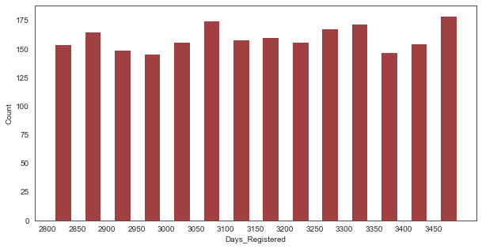

```python
fig, axes = plt.subplots(figsize=(10, 5))
ax = sns.histplot(data=data['Days_Registered'], color= 'Maroon', shrink=.55)
ax.set_xticks([2800,2850,2900,2950,3000,3050,3100,3150,3200,3250,3300,3350,3400,3450]);
data.Days_Registered.describe()
```

Distribution of the data seems fair.

### Spending

Create "Spending" adding total amount spent in various categories over the span of two years.

```python
column_names = ['MntWines', 'MntFruits', 'MntMeatProducts', 'MntFishProducts', 'MntSweetProducts', 'MntGoldProds']
data['Spending'] = data[column_names].sum(axis=1)
```

```
count    2240.000000
mean      605.798214
std       602.249288
min         5.000000
25%        68.750000
50%       396.000000
75%      1045.500000
max      2525.000000
Name: Spending, dtype: float64
```

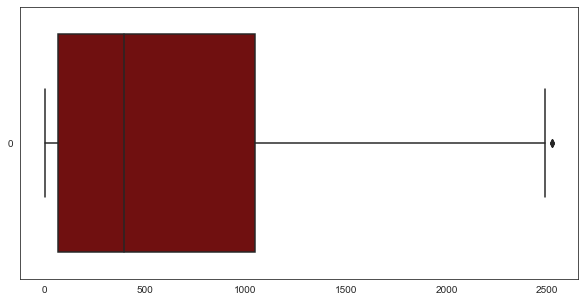

```python
fig, axes = plt.subplots(figsize=(10, 5))
sns.boxplot(data=data['Spending'], color= 'Maroon', orient="h" );
data.Spending.describe()
```

Though there seem to be some outliers we will calculate the percentile values between 75% and 100% also

```python
print(color.BOLD +"80% value in Spending is {}".format(round(data.Spending.quantile(0.8),2)), "\n"+ color.END)
print(color.BOLD +"90% value in Spending is {}".format(round(data.Spending.quantile(0.9),2)), "\n"+ color.END)
print(color.BOLD +"99% value in Spending is {}".format(round(data.Spending.quantile(0.99),2)), "\n"+ color.END)
```

```
80% value in Spending is 1174.0

90% value in Spending is 1536.2

99% value in Spending is 2126.0
```

Based on the percentile value we will not consider the entry above 2500 as outlier.

```python
#data['Spending'] = np.where(data['Spending'] > 2400, 2400, data['Spending'])
```

```python
#data['Spending'].loc[105]
```

### NumTotalPurchases

Create "NumTotalPurchases" adding purchases from various sources.

```python
column_names = ['NumWebPurchases', 'NumCatalogPurchases', 'NumStorePurchases']
data['NumTotalPurchases'] = data[column_names].sum(axis=1)
```

```
Number of unique values in NumTotalPurchases is 33
```

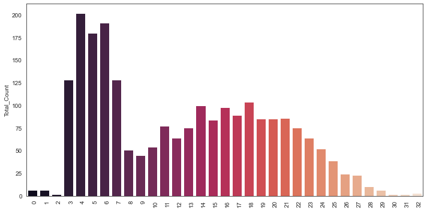

```python
count_uniques = pd.DataFrame(data['NumTotalPurchases'].value_counts()).rename(columns={'NumTotalPurchases':'Total_Count'}).sort_values('Total_Count',ascending=False)

# parameters in format function.
print(color.BOLD +"Number of unique values in NumTotalPurchases is {}".format(count_uniques.shape[0]), "\n"+ color.END)

# Create Figure
fig, ax = plt.subplots(figsize=(10,5))

ax = sns.barplot(x=count_uniques.index.values.tolist()  , y="Total_Count", data=count_uniques, palette= 'rocket')
# rotates labels and aligns them horizontally to left
plt.setp( ax.xaxis.get_majorticklabels(), rotation=90, ha="left" )

plt.tight_layout()
plt.show()
```

### NumPromoAccepted

Create "NumPromoAccepted" adding all promotions accepted.

```python
column_names = ['AcceptedCmp1', 'AcceptedCmp2', 'AcceptedCmp3', 'AcceptedCmp4', 'AcceptedCmp5' ]
data['NumPromoAccepted'] = data[column_names].sum(axis=1)
```

```
Number of unique values in NumPromoAccepted is 5
```

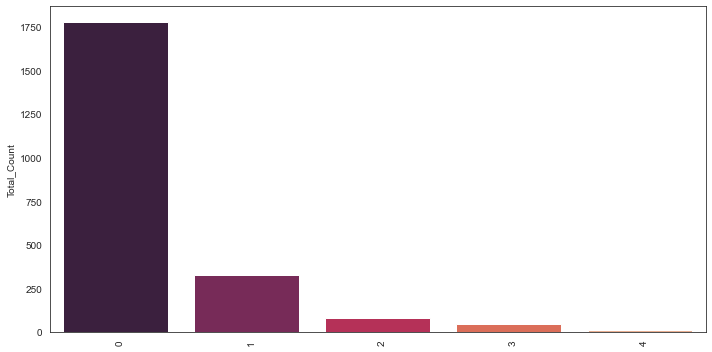

```python
count_uniques = pd.DataFrame(data['NumPromoAccepted'].value_counts()).rename(columns={'NumPromoAccepted':'Total_Count'}).sort_values('Total_Count',ascending=False)

# parameters in format function.
print(color.BOLD +"Number of unique values in NumPromoAccepted is {}".format(count_uniques.shape[0]), "\n"+ color.END)

# Create Figure
fig, ax = plt.subplots(figsize=(10,5))

ax = sns.barplot(x=count_uniques.index.values.tolist()  , y="Total_Count", data=count_uniques, palette= 'rocket')
# rotates labels and aligns them horizontally to left
plt.setp( ax.xaxis.get_majorticklabels(), rotation=90, ha="left" )

plt.tight_layout()
plt.show()
```

# Multi Variate Analysis

```
Correlation between Income', 'Spending', 'NumTotalPurchases', 'Age' is

                     Income  Spending  NumTotalPurchases       Age
Income             1.000000  0.792650           0.741975  0.197848
Spending           0.792650  1.000000           0.820687  0.112838
NumTotalPurchases  0.741975  0.820687           1.000000  0.174618
Age                0.197848  0.112838           0.174618  1.000000

Pair plot between Income', 'Spending', 'NumTotalPurchases', 'Age'
```

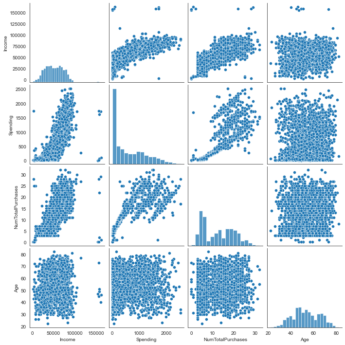

```python
numeric_variables = data[['Income', 'Spending', 'NumTotalPurchases', 'Age']]
corr= numeric_variables.corr()
print(color.BOLD+color.BLUE  +"Correlation between Income', 'Spending', 'NumTotalPurchases', 'Age' is ", "\n"+ color.END)
print(corr,"\n")
print(color.BOLD+color.BLUE  +"Pair plot between Income', 'Spending', 'NumTotalPurchases', 'Age' ", "\n"+ color.END)
sns.pairplot(numeric_variables);
```

*Age is least correlated with Income, Spending and NumTotalPurchases.  
*Days_Registered has low correlation between Spending and NumTotalPurchases

```
Correlation between variables  is Days_Registered, Spending, NumTotalPurchases, NumPromoAccepted

                   Days_Registered  Spending  NumTotalPurchases  \
Days_Registered           1.000000  0.158814           0.162911
Spending                  0.158814  1.000000           0.820687
NumTotalPurchases         0.162911  0.820687           1.000000
NumPromoAccepted         -0.011366  0.459554           0.307342

                   NumPromoAccepted
Days_Registered           -0.011366
Spending                   0.459554
NumTotalPurchases          0.307342
NumPromoAccepted           1.000000

Pair plot between Days_Registered, Spending, NumTotalPurchases based on NumPromoAccepted
```

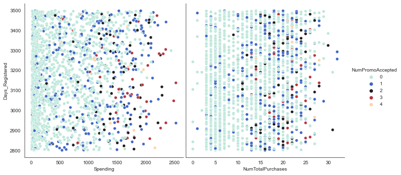

```python
print(color.BOLD+color.BLUE  +"Correlation between variables  is Days_Registered, Spending, NumTotalPurchases, NumPromoAccepted ", "\n"+ color.END)
print(data[["Days_Registered", "Spending", "NumTotalPurchases", "NumPromoAccepted"]].corr(),"\n")
print(color.BOLD+color.BLUE  +"Pair plot between Days_Registered, Spending, NumTotalPurchases based on NumPromoAccepted", "\n"+ color.END)
sns.pairplot( data,
             x_vars=["Spending", "NumTotalPurchases"],
             y_vars=["Days_Registered"], hue= "NumPromoAccepted",height=5, aspect=1/1, palette="icefire");
```

*Age has least correlation with Income, Spending and NumTotalPurchases.  
*Days_Registered has low correlation between Spending and NumTotalPurchases

```
Correlation between variables Income, Spending,NumPromoAccepted

                    Income  Spending  NumPromoAccepted
Income            1.000000  0.792650          0.366384
Spending          0.792650  1.000000          0.459554
NumPromoAccepted  0.366384  0.459554          1.000000

Income vs Spending scatter plot with number of promotions applied
```

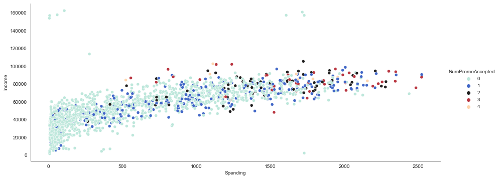

```python
print(color.BOLD+color.BLUE  +"Correlation between variables Income, Spending,NumPromoAccepted", "\n"+ color.END)
print(data[["Income", "Spending","NumPromoAccepted"]].corr(),"\n")
print(color.BOLD+color.BLUE  +"Income vs Spending scatter plot with number of promotions applied", "\n"+ color.END)
sns.pairplot( data, x_vars=["Spending"], y_vars=["Income"],
             hue= "NumPromoAccepted", palette="icefire", height=5, aspect=2.5/1);
```

```
Total spending on Wines, Fruits, MeatProducts, FishProducts, SweetProducts, GoldProds wrt to NumPromoAccepted
```

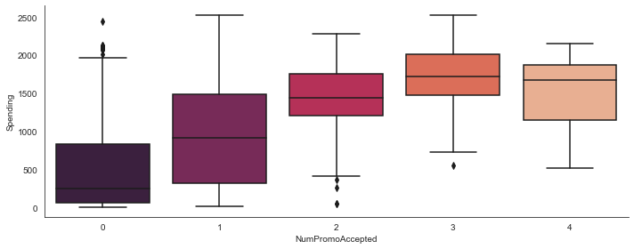

```python
print(color.BOLD+color.BLUE  +"Total spending on Wines, Fruits, MeatProducts, FishProducts, SweetProducts, GoldProds wrt to NumPromoAccepted"+ color.END)
sns.catplot(x="NumPromoAccepted", y="Spending", kind="box", data=data, height=4, aspect=2.5/1, palette='rocket');
```

*customers using 1, 2 or 3 promotions are spending more  
*Customers earning between 40000 to 100000 are using more promotions

# Missing Value Treatment

```python
# printing variable name and number of null values if any
print(color.BOLD+color.BLUE +"printing variable name and number of null values if any"+ color.END)
col_name = data.isnull().sum(axis=0).sort_values(ascending = False)
col_name
```

```
printing variable name and number of null values if any
```

```
Income                 25
ID                      0
Response                0
AcceptedCmp4            0
AcceptedCmp5            0
AcceptedCmp1            0
AcceptedCmp2            0
Complain                0
Z_CostContact           0
Z_Revenue               0
Children                0
NumWebVisitsMonth       0
Family_Size             0
Relation_status         0
Age                     0
Days_Registered         0
Spending                0
NumTotalPurchases       0
AcceptedCmp3            0
NumStorePurchases       0
Year_Birth              0
MntWines                0
Education               0
Marital_Status          0
Kidhome                 0
Teenhome                0
Dt_Customer             0
Recency                 0
MntFruits               0
NumCatalogPurchases     0
MntMeatProducts         0
MntFishProducts         0
MntSweetProducts        0
MntGoldProds            0
NumDealsPurchases       0
NumWebPurchases         0
NumPromoAccepted        0
dtype: int64
```

There are 25 missing values in Income variable.  
We will replace the income with group mean of education and age.

# missing = data[data['Income'].isna()].index

```python
data['Income'] = data['Income'].fillna(data.groupby(['Education','Age'])['Income'].transform('mean'))
#data.iloc[missing, :]
```

# Drop Redundant Variables

```python
data[['Z_CostContact', 'Z_Revenue']].describe()
```

|  | Z_CostContact | Z_Revenue |
| --- | --- | --- |
| count | 2240.0 | 2240.0 |
| mean | 3.0 | 11.0 |
| std | 0.0 | 0.0 |
| min | 3.0 | 11.0 |
| 25% | 3.0 | 11.0 |
| 50% | 3.0 | 11.0 |
| 75% | 3.0 | 11.0 |
| max | 3.0 | 11.0 |

'Z_CostContact', 'Z_Revenue both these variables have repeated values we will delete both variables

```python
#Drop redundant variables
to_drop = ['ID', 'Year_Birth', 'Marital_Status', 'Dt_Customer', 'Z_CostContact', 'Z_Revenue']
data = data.drop(to_drop, axis=1)
```

# Correlation heat map between Various variables

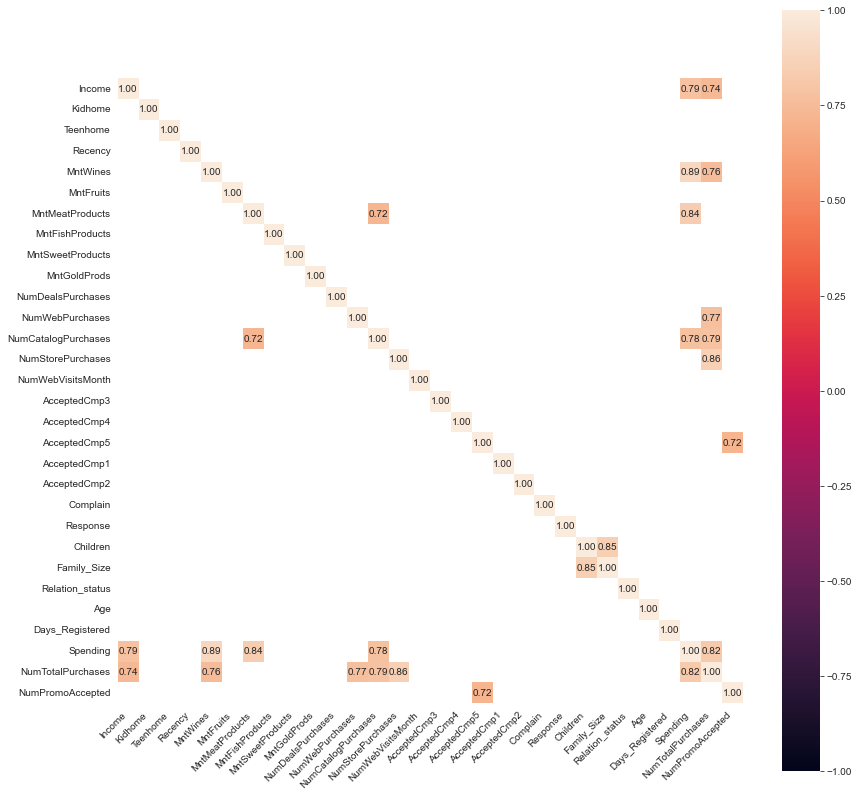

```python
corr= data.corr()

fig, ax = plt.subplots(figsize=(14,14))

ax = sns.heatmap(corr, vmin=-1, vmax=1, center=0, mask = np.abs(corr)<.7,cmap=sns.color_palette("rocket", as_cmap=True), square=True, annot=True, fmt='.2f')
#ax = sns.heatmap(corr, vmin=-1, vmax=1, center=0, cmap=sns.color_palette("rocket", as_cmap=True), square=True, annot=True, fmt='.2f')

ax.set_xticklabels(ax.get_xticklabels(), rotation=45,horizontalalignment='right');
```

Based on the above correlation heat map we delete Variables that are used to create variables such as  
Spending, NumTotalPurchases and NumPromoAccepted as they have captured the essence of Individual columns

```python
#create copy of dataframe for later
data_copy = data.copy()
```

```python
to_drop = ['NumWebPurchases', 'NumCatalogPurchases', 'NumStorePurchases',
           'MntWines', 'MntFruits', 'MntMeatProducts', 'MntFishProducts', 'MntSweetProducts', 'MntGoldProds',
          'AcceptedCmp1', 'AcceptedCmp2', 'AcceptedCmp3', 'AcceptedCmp4', 'AcceptedCmp5']
data = data.drop(to_drop, axis=1)
```